# Python in R

2019-11-10

## Introduction

```r
### create a new environment
# conda_create("nlp")
### install modules
# conda_install("nlp", c("gensim", "networkx", "numpy"))

# indicate that we want to use a specific condaenv
library(reticulate)
use_condaenv(condaenv = "nlp")
```

- Access to objects created within Python chunks from R using the `py` object (e.g. `py$x` would access an `x` variable created within Python from R).
- Access to objects created within R chunks from Python using the `r` object (e.g. `r.x` would access to `x` variable created within R from Python).

```python
## Python chunk
a = [1, 2, 5, "a"]
a
```

```
[1, 2, 5, 'a']
```

```python
a.append("c")
a
```

```
[1, 2, 5, 'a', 'c']
```

```r
## R chunk
names(py$a) <- letters[1:5]
py$a    ## also can be used with stuff like dplyr::bind_rows() or tibble::enframe()
```

```
$a
[1] 1

$b
[1] 2

$c
[1] 5

$d
[1] "a"

$e
[1] "c"
```

The translation between languages is somewhat awkward. Notice that we turned `py$a` into a *named list*, which in Python implies a `list` to `dictionary` convertion.

```python
## Python chunk
a
```

```
{'a': 1, 'b': 2, 'c': 5, 'd': 'a', 'e': 'c'}
```

```r
## R chunk
## import NumPy (it will be automatically discovered in "r-reticulate")
np <- import("numpy", convert = TRUE)
np$random$random(10L)
```

```
 [1] 0.5999452843 0.6170888346 0.1995379695 0.1430141465 0.0004201711
 [6] 0.7878022959 0.2619967849 0.2479578051 0.1330800837 0.1125367686
```

```python
## Python chunk
import numpy as np
b = np.identity(3)
b
```

```
array([[1., 0., 0.],
       [0., 1., 0.],
       [0., 0., 1.]])
```

```python
b.shape
```

```
(3, 3)
```

```r
## R chunk
py$b
```

```
     [,1] [,2] [,3]
[1,]    1    0    0
[2,]    0    1    0
[3,]    0    0    1
```

```r
dim(py$b)
```

```
[1] 3 3
```

```python
## Python list comprehesion using an R object
[w for w in r.fruit if len(w) >= 12]
```

```
['blackcurrant', 'blood orange', 'canary melon', 'chili pepper', 'passionfruit', 'purple mangosteen']
```

**Using Python functions**

```python
def flip(p):
    return np.random.random() < p
```

```python
## Python chunk
flip(0.5)
```

```
True
```

```r
## R chunk
replicate(10, py$flip(0.3))
```

```
 [1] FALSE FALSE FALSE FALSE FALSE  TRUE FALSE  TRUE FALSE FALSE
```

```python
def all_pairs(nodes):
    for i, u in enumerate(nodes):
        for j, v in enumerate(nodes):
            if i>j:
                yield u, v

def random_pairs(nodes, p):
    for edge in all_pairs(nodes):
        if flip(p):
            yield edge

import networkx as nx
def make_random_graph(n, p):
    G = nx.Graph()
    nodes = range(n)
    G.add_nodes_from(nodes)
    G.add_edges_from(random_pairs(nodes, p))
    return G
```

```python
G = make_random_graph(n = 80, p = 0.01)
G = nx.adjacency_matrix(G).asformat("array")
```

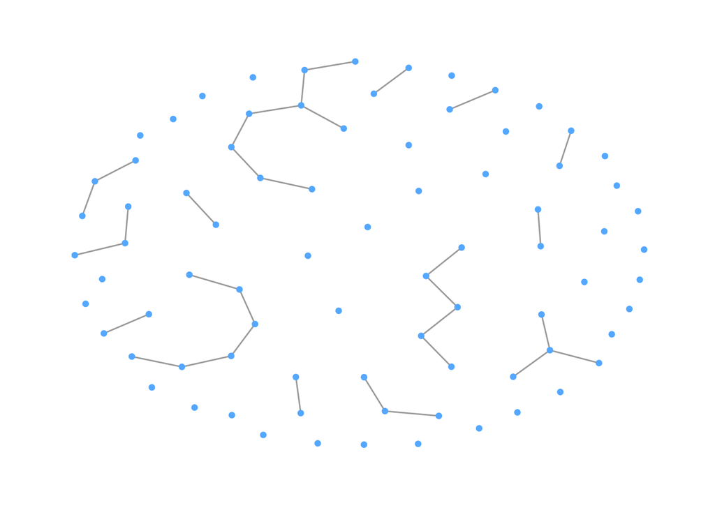

```r
library(ggraph)
py$G %>%
  igraph::graph_from_adjacency_matrix(mode = "undirected") %>%
  ggraph(layout = "kk") +
  geom_edge_fan(alpha = 0.4) +
  geom_node_point(col = "steelblue1") +
  theme_graph()
```

## Other

There are many more things that **`reticulate`** allows us to do (see [here](https://rstudio.github.io/reticulate/reference/index.html)).

Here are just a couple of interesting tidbits:

```r
## R chunk
keys <- c("a", "b", "c")
values <- 1:3
py_dict(keys, values)
```

```
{'a': 1, 'b': 2, 'c': 3}
```

```r
py_dict(keys, values) %>% py_len()
```

```
[1] 3
```

```r
## More complex objects
dict(list("andrés" = tuple(1, 2, 3)))
```

```
{'andrés': (1.0, 2.0, 3.0)}
```

Creating Numpy arrays with `np_array()` and `array_reshape()` might come in handy too.

Finally, as of now RStudio’s environment panel doesn’t display the contents of the Python environment. There’s no current analog to “magic commands” in Jupyter Notebooks (i.e. `%whos`), but these are a couple of ways around this problem:

- Solution 1: Use the tab-complete feature in RStudio when typing `py$...`
- Solution 2: Use `rlang::env_names(py)`

  ```r
  rlang::env_names(py)
  ```

  ```
   [1] "a"                 "all_pairs"         "b"
   [4] "flip"              "G"                 "make_random_graph"
   [7] "np"                "nx"                "r"
  [10] "R"                 "random_pairs"      "sys"
  ```

- Solution 3: Write a function

  ```r
  print_py_env <- function() {
    py_obj <<- rlang::env_names(py)
    py_run_string("r.py_typeof = [str(type(eval(x))) for x in r.py_obj]")
    py_typeof <- stringr::str_replace(py_typeof, "<class '(.*)'>", "\\1")
    return(tibble::tibble(py_obj, py_typeof))
  }

  print_py_env()
  ```

  ```
  # A tibble: 12 x 2
     py_obj            py_typeof
     <chr>             <chr>
   1 a                 dict
   2 all_pairs         function
   3 b                 numpy.ndarray
   4 flip              function
   5 G                 numpy.ndarray
   6 make_random_graph function
   7 np                module
   8 nx                module
   9 r                 __main__.R
  10 R                 type
  11 random_pairs      function
  12 sys               module
  ```

  But this creates two additional variables in our global environment…
- Solution 4: Wait until RStudio creates an addin.